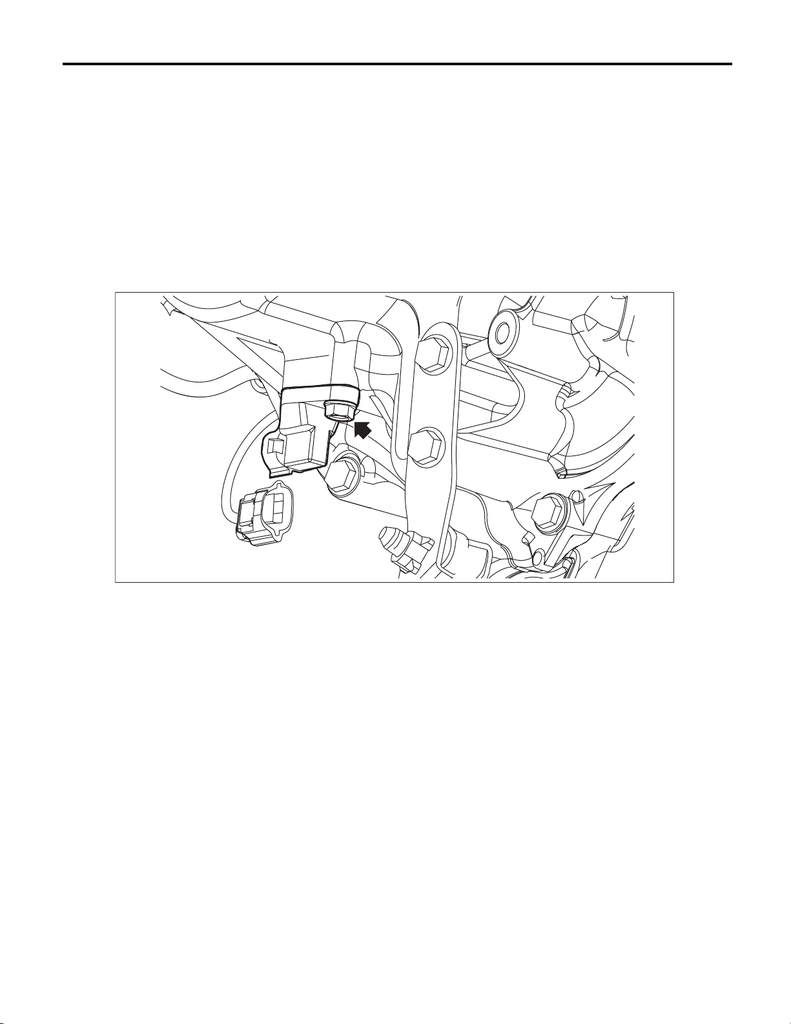

CVT(TR690)-105

Front Wheel Speed Sensor

CONTINUOUSLY VARIABLE TRANSMISSION

17.Front Wheel Speed Sensor

A: REMOVAL

CAUTION:

• Be sure to prevent water or oil from contacting the connector terminal of front wheel speed sensor.

If adhesion occurs, replace with a new part.

• When removing front wheel speed sensor, CVTF may let out. If CVTF has leaked, adjust the CVTF

level after installing the front wheel speed sensor.

1) Disconnect the ground terminal from battery sensor. <Ref. to NT-5, BATTERY, NOTE, Note.>

2) Lift up the vehicle.

3) Clean the transmission exterior.

4) Remove the front wheel speed sensor harness connector.

5) Remove the front wheel speed sensor.

B: INSTALLATION

CAUTION:

• Be sure to prevent water or oil from contacting the connector terminal of front wheel speed sensor.

If adhesion occurs, replace with a new part.

• After installing the front wheel speed sensor, adjust the CVTF level.

Install in the reverse order of removal.

NOTE:

• Use new O-rings.

• Apply CVTF to the O-ring.

Tightening torque:

5 N·m (0.5 kgf-m, 3.7 ft-lb)

AT-07419

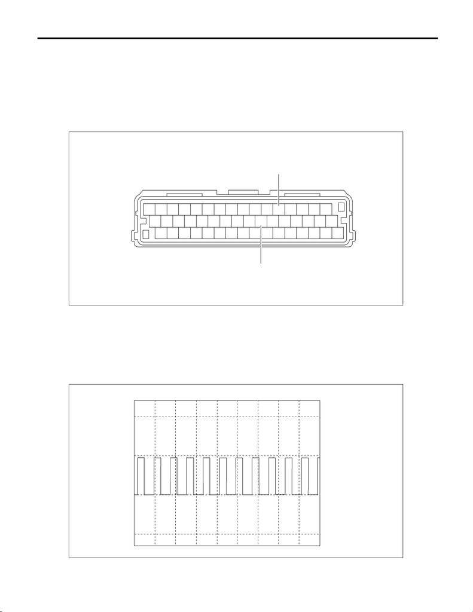

CVT(TR690)-106

Front Wheel Speed Sensor

CONTINUOUSLY VARIABLE TRANSMISSION

C: INSPECTION

1) Remove the bulkhead harness connector from TCM. <Ref. to CVT(TR690)-126, REMOVAL, Transmis-

sion Control Module (TCM).>

2) Set the ST between the TCM and bulkhead harness.

ST 18460AA040 CHECK BOARD

3) Set the probe of oscilloscope to the check board connector.

Terminals:

No. 12 (+) — No. 26 (–)

4) Lift up the vehicle and raise the vehicle speed up to 20 km/h (12 MPH).

5) Check the waveform of front wheel speed sensor when vehicle speed is at 20 km/h (12 MPH).

NOTE:

The waveform cycle changes as the speed changes.

(A) + probe

(B) – probe

123456789

10 11 12 13 14 15 16

17 18 19 20 21 22 23 24 25 26 27 28 29 30 31 32

33 34 35 36 37 38 39 40 41 42 43 44 45 46 47 48

(A)

CVT00512

(B)

AT-08036

0

5

-5

10

(V)